```python
intro_images_path='../dataset_part1/Images/Intro_images/'
edge_images_path='../dataset_part1/Images/Edge_images/'
seg_images_path='../dataset_part1/Images/Seg_images/'
feature_images_path='../dataset_part1/Images/Feature_images/'
output_path='./Images/Outputs/'
print('Image paths ....')
```

```
Image paths ....
```

# COMPUTER VISION I

**Master in Artificial Intelligence, USC, UDC, UVigo**

Academic year 2023/24

[figure not shown]

### EXERCISE 3

Consider the image naval.jpg. Try to detect lines with the best trade-off between the numbers of True Positive lines and False Negative ones. Consider different levels of smoothing when applying Canny detector.

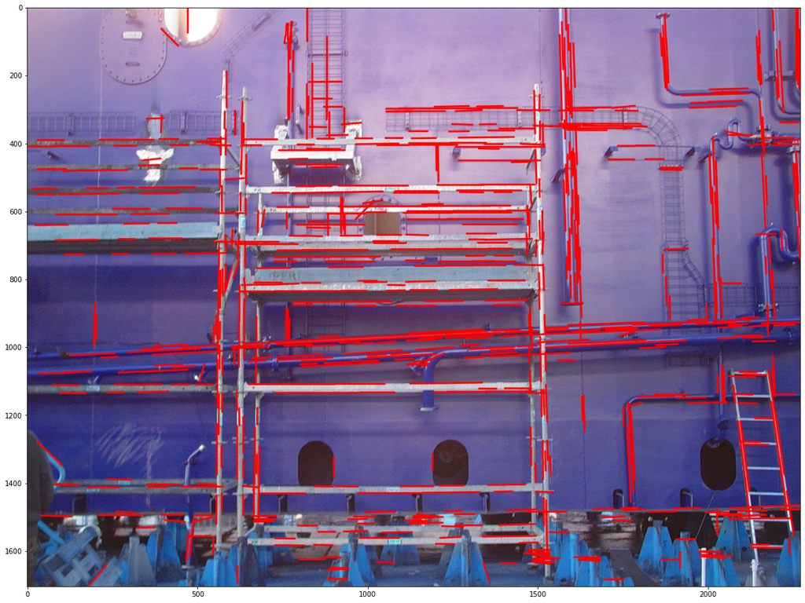

```python
#SOLUTION HERE

import cv2
import numpy as np
import math
from matplotlib import pyplot as plt

img = cv2.imread(edge_images_path+'naval.jpg')
gray = cv2.cvtColor(img,cv2.COLOR_BGR2GRAY)
gray=img
imgP=img.copy()

gray = cv2.GaussianBlur(img,(9,9),0)
edges = cv2.Canny(gray,1,50,apertureSize=3,L2gradient=True)
lines = cv2.HoughLines(edges,1,np.pi/180,120)

linesP = cv2.HoughLinesP(edges,1,np.pi/180,50,
                 minLineLength=50,maxLineGap=10)

imgP=img.copy()

if linesP is not None:
   for i in range(0, len(linesP)):
      l = linesP[i][0]
      cv2.line(imgP, (l[0], l[1]), (l[2], l[3]), (255,0,0), 3, cv2.LINE_AA)

plt.figure(figsize=(20, 20))
plt.imshow(imgP)
plt.show()
```

After trying several configurations both in GaussianBlur, as with the Canny detector, and the Hough detector, this is the result that I think best fits, although I am not sure how the final result should look like.

### ExERCISE 4

Implement a program for the estimation of the number of fishes in fishes.jpg image, according to the number of detected eyes. Choose the most convenient parameters.

```
Number of detected fishes:  14
```

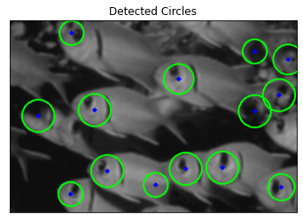

```python
#SOLUTION HERE
import numpy as np
import cv2
from matplotlib import pyplot as plt

img = cv2.imread(edge_images_path+'fishes.jpg',0)
img = cv2.GaussianBlur(img,(11,11),2)

cimg = cv2.cvtColor(img,cv2.COLOR_GRAY2BGR)


circles = cv2.HoughCircles(img,cv2.HOUGH_GRADIENT,dp=2,minDist=30, param1=40,param2=40,minRadius=20,maxRadius=29)
circles = np.uint16(np.around(circles))
print('Number of detected fishes: ',len(circles[0]))
for i in circles[0,:]:
    # draw the outer circle
    cv2.circle(cimg,(i[0],i[1]),i[2],(0,255,0),2)
    # draw the center of the circle
    cv2.circle(cimg,(i[0],i[1]),2,(0,0,255),3)

plt.imshow(cimg)
plt.title('Detected Circles'), plt.xticks([]), plt.yticks([])
plt.show()
```

In this exercise, the main parameters that have been adjusted for fish detection have been the minRadius and maxRadius parameters. Although the GaussianBlur values have also been touched. With these changes all the fishes (11) are detected but there are three major detections that are erroneous. We have tried to vary the parameters to try to improve these detections but this is the best result obtained.